# Analyzing how sampling method affects estimates of specialization

**Overall questions:**

1. How does sampling method (pollen vs. camera) affect the apparent level of ecological specialization between plants and hummingbirds?
- Predict that pollen networks are less specialized (more generalized) than visitation networks, because they sample a larger spatial extent.
2. How well does one sampling method approximate the other sampling method?
- Predict that correlation could be relatively low, given the inherent differences in how data were collected. Pollen networks are created from capturing hummingbirds over just a few hours but may include pollen grains from plants over a large spatial extent (depending on hummingbird movement and pollen carryover between flowers). Camera networks are created from observations across multiple entire days, but spatial extent is limited.

**Approach**

Analyze networks sampled from the “pre” period of the Heliconia removal experiment; these data can be considered to reflect ‘normal’ visitation, unaffected by our experiment. Limit this analysis to replicates that have networks representing both sampling methods. A replicate is a patch + year combination.

1. Across replicates, does one sampling method lead to higher (or lower) specialization estimates than the other method?
- MODEL: specialization metric ~ sampling method + (1|patch/year) *-> x3 specialization metrics*
- DATA FORMAT: two rows per replicate (1 row pollen, 1 row camera)
2. How correlated are pollen and visitation networks within a replicate?
- MODEL: specialization metric pollen ~ specialization metric camera + (1|patch) *-> x3 specialization metrics*
- DATA FORMAT: one row per replicate (1 column pollen, 1 column camera)

## Step 1: Get data

```r
#Data are currently in long format (created in script 04). Will stick with this format for the initial analysis
data <- read.csv("../data/export/for_analysis/Network_specialization_for_analysis.csv") %>%
  filter(exp_phase == "pre") %>%
  filter(bird_group == "all_spp") %>%
  select(-unpaired, -X) %>%
  arrange(metric) %>%
  mutate(year_patch = paste(year, patch, sep = "_")) %>%
  select(year, patch, year_patch, everything())

#Remove unpaired networks by switching to wide form and then switching back
#Here, unpaired network = missing either a pollen network or visitation network from same time replicate (patch + year)
#Note: this is a different meaning than in script 04, where I flagged networks that didn't have a complete pre-to-post pair
data_long <- data %>%
  pivot_wider(names_from = "sampling_method", values_from = value) %>%
  filter(!is.na(pollen) & !is.na(visitation)) %>%
  pivot_longer(cols = c("pollen", "visitation"), names_to = "sampling_method")

#Functions
source("../scripts/helper_functions/Calculate_basic_summary_stats.R")
source("../scripts/helper_functions/Transform_proportion_for_betareg.R")
source("../scripts/helper_functions/Modeling_helper_functions.R")
```

## Step 2: Are camera networks more specialized than pollen networks?

**Explore data**

```r
#What are ranges of each response variable?
response_variable_sum <- data_long %>%
  group_by(metric) %>%
  calculate_basic_summary_stats(value)

response_variable_sum
```

```
## # A tibble: 3 × 7
##   metric                      min   max  mean    sd median     n
##   <chr>                     <dbl> <dbl> <dbl> <dbl>  <dbl> <int>
## 1 d                             0 0.691 0.330 0.218  0.368    40
## 2 H2                            0 0.806 0.349 0.255  0.321    40
## 3 species.specificity.index     0 0.835 0.563 0.163  0.606    40
```

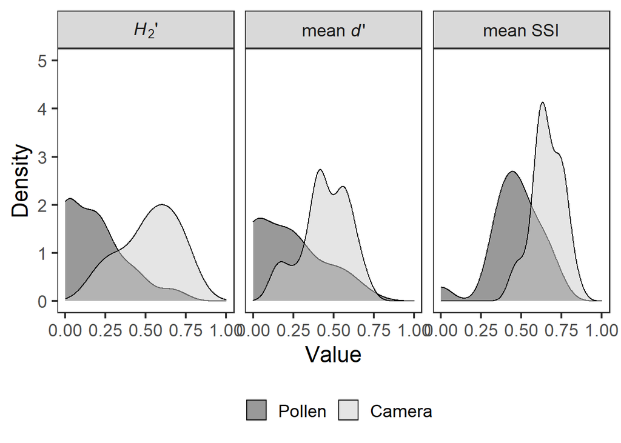

```r
#Are visitation networks more specialized than pollen networks, as predicted?
#Make a plot to visually examine. Will also analyze statistically in next step
h2_label <- expression(paste(italic(H[2])*"'"))
d_label <- expression(paste("mean "*italic(d)*"'"))
ssi_label <- expression("mean~SSI")

#As density plot
specialization_density_plot <- data_long %>%
  mutate(sampling_method = factor(sampling_method, levels = c("pollen", "visitation"), labels = c("Pollen", "Camera"))) %>%
  mutate(metric = factor(metric, levels = c("H2", "d", "species.specificity.index"), labels = c(h2_label, d_label, ssi_label))) %>%
  ggplot(., aes(x = value, fill = sampling_method)) +
    facet_grid(.~metric, labeller = label_parsed) +
    geom_density(alpha = 0.5) +
    theme_bw(base_size = 18) +
    theme(legend.position = "bottom") +
    theme(panel.grid.minor = element_blank(), panel.grid.major = element_blank()) +
    scale_fill_grey(name = "") +
    labs(x = "Value", y = "Density", color = "sampling_method", fill = "sampling_method") +
    xlim(0,1) +
    ylim(0,5)

specialization_density_plot
```

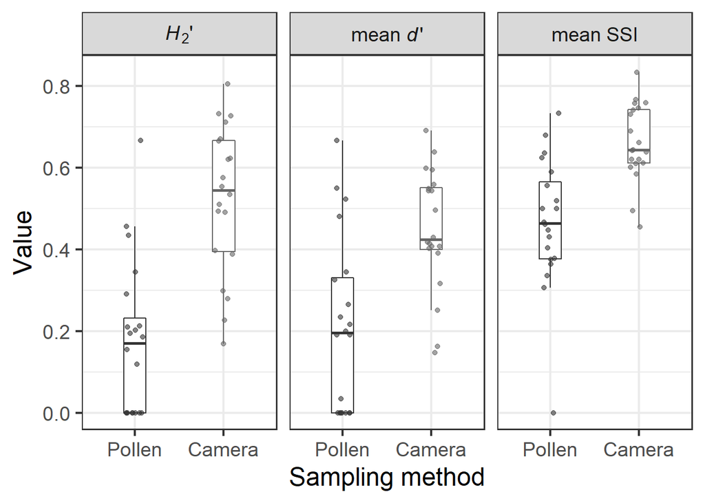

```r
#As boxplot
specialization_boxplot <- data_long %>%
  mutate(sampling_method = factor(sampling_method, levels = c("pollen", "visitation"), labels = c("Pollen", "Camera"))) %>%
  mutate(metric = factor(metric, levels = c("H2", "d", "species.specificity.index"), labels = c(h2_label, d_label, ssi_label))) %>%
  ggplot(aes(x = sampling_method, y = value, color = sampling_method)) +
    geom_boxplot(width = 0.25, outlier.shape = NA) +
    geom_jitter(alpha = 0.6, width = 0.1) +
    facet_grid(.~metric, labeller = label_parsed) +
    theme_bw(base_size = 18) +
    theme(legend.position = "none") +
    scale_color_manual(values = c("grey20", "grey40")) +
    labs(x = "Sampling method", y = "Value")

specialization_boxplot
```

Range of response variables is essentially a proportion, ranging from 0-1 (but in this case not including 1)

Will use beta regression after transforming response variable to not include zero following [Cribari-Neto & Zeileis 2010] (https://www.jstatsoft.org/article/view/v034i02)

**Transform response**

```r
#For beta regression, transform response using method of Cribari-Neto & Zeileis 2010 to remove zeroes
data_long_transform <- data_long %>%
  group_by(sampling_method, metric) %>%
  mutate(value_transform = transform_proportion(value)) %>%
  ungroup()
```

**Create models**

```r
#Ideal RE structure would be (1|patch/year), which is equivalent to (1|patch) + (1|year_patch)

#BETA REGRESSION (GLMM)
model1 <- glmmTMB(value_transform ~ sampling_method + (1|patch) + (1|year_patch), data = filter(data_long_transform, metric == "H2"), family = beta_family(link="logit"))
model2 <- glmmTMB(value_transform ~ sampling_method + (1|patch) + (1|year_patch), data = filter(data_long_transform, metric == "d"), family = beta_family(link="logit"))
model3 <- glmmTMB(value_transform ~ sampling_method + (1|patch) + (1|year_patch), data = filter(data_long_transform, metric == "species.specificity.index"), family = beta_family(link="logit"))

simulateResiduals(model1, n = 1000) %>% plot()
```

[output not shown]

```r
simulateResiduals(model2, n = 1000) %>% plot()
```

```r
simulateResiduals(model3, n = 1000) %>% plot()
```

```r
check_singularity(model1)
check_singularity(model2)
check_singularity(model3)

#All assumptions look OK, except that DHARMa test for homoscedasticity seems a bit suspicious for model 2.
#This can also be seen in boxplot created during exploration of raw data; i.e., more spread in pollen than visitation
#These resources suggest that allowing for variable dispersion with dispformula would be an option:
#https://stackoverflow.com/questions/52649486/accounting-for-heteroscedasticity-across-groups-in-a-glmmtmb-with-a-beta-distrib
#https://github.com/florianhartig/DHARMa/issues/126

model2 <- update(model2, dispformula = ~sampling_method)
simulateResiduals(model2, n = 1000) %>% plot()
```

[output not shown]

```r
#Looks better!
#Sneak peek at results...
summary(model1)
summary(model2)
summary(model3)

ggeffects::ggpredict(model1) %>% plot(add.data = TRUE, jitter = c(0.15, 0))
```

[output not shown]

```r
ggeffects::ggpredict(model2) %>% plot(add.data = TRUE, jitter = c(0.15, 0))
```

```r
ggeffects::ggpredict(model3) %>% plot(add.data = TRUE, jitter = c(0.15, 0))
```

```r
#Combine models into dataframe
specialization_models <- tibble(model_number = c(1, 2, 3),
                                metric = c("H2", "d", "species.specificity.index"),
                                model = list(model1, model2, model3))
```

## Step 3: How correlated are metrics from networks sampled during same time period, but using different methods?

**Explore data**

```r
#Convert to wide format
data_wide_transform <- data_long_transform %>%
  pivot_wider(names_from = "sampling_method", values_from = c(value, value_transform), names_glue = "{sampling_method}_{.value}")

#Explore raw data
#Note: geom_smooth with linear model does not account for grouping structure within data, so just for exploration purposes, not inference!
correlation_plot <- data_wide_transform %>%
  mutate(metric = factor(metric, levels = c("H2", "d", "species.specificity.index"), labels = c(h2_label, d_label, ssi_label))) %>%
  ggplot(aes(x = visitation_value, y = pollen_value)) +
    geom_smooth(method = "lm", colour = "black") +
    geom_point(alpha = 0.6) +
    facet_grid(.~metric, labeller = label_parsed) +
    theme_bw(base_size = 18) +
    labs(x = "Visitation network", y = "Pollen network")

correlation_plot
#Looks like there is an outlier for SSI (2018_60). Will run with and without to see how sensitive results are to this value
```

[output not shown]

**Create models**

```r
#BETA REGRESSION (GLMM)
model4 <- glmmTMB(pollen_value_transform ~ visitation_value_transform + (1|patch) , data = filter(data_wide_transform, metric == "H2"), family = beta_family(link="logit"))

model5 <- glmmTMB(pollen_value_transform ~ visitation_value_transform + (1|patch), data = filter(data_wide_transform, metric == "d"), family = beta_family(link="logit"))

model6 <- glmmTMB(pollen_value_transform ~ visitation_value_transform + (1|patch), data = filter(data_wide_transform, metric == "species.specificity.index"), family = beta_family(link="logit"))

model6_no_outlier <- glmmTMB(pollen_value_transform ~ visitation_value_transform + (1|patch), data = filter(data_wide_transform, metric == "species.specificity.index" & year_patch != "2018_60"), family = beta_family(link="logit"))

simulateResiduals(model4, n = 1000) %>% plot()
```

[output not shown]

```r
simulateResiduals(model5, n = 1000) %>% plot()
```

```r
simulateResiduals(model6, n = 1000) %>% plot()
```

```r
simulateResiduals(model6_no_outlier, n = 1000) %>% plot()
```

```r
check_singularity(model4)
check_singularity(model5)
check_singularity(model6)
check_singularity(model6_no_outlier)

#Sneak peek at results...in model 6, sign of of coefficient changes after removing outlier
summary(model4)
summary(model5)
summary(model6)
summary(model6_no_outlier)

ggeffects::ggpredict(model4) %>% plot(add.data = TRUE, jitter = 0)
```

[output not shown]

```r
ggeffects::ggpredict(model5) %>% plot(add.data = TRUE, jitter = 0)
```

```r
ggeffects::ggpredict(model6) %>% plot(add.data = TRUE, jitter = 0)
```

```r
ggeffects::ggpredict(model6_no_outlier) %>% plot(add.data = TRUE, jitter = 0)
```

```r
#Combine models into dataframe
correlation_models <- tibble(model_number = c(4, 5, 6),
                             metric = c("H2", "d", "species.specificity.index"),
                             model = list(model4, model5, model6_no_outlier))

#Calculate pseudo r-squared
#Conditional R2= entire model, fixed AND random effects
#Marginal R2 = fixed effects
#Cannot get conditional pseudo-R2 for singular fits. Looks like I'd need to remove RE and run models outside of glmmTMB to get those calculations
r2(model4)
r2(model5)
r2(model6)
r2(model6_no_outlier)
```

## Step 4: Compile and plot results

**Create model summaries, calculate confidence intervals, and tidy results into dataframe for export**

```r
results <- specialization_models %>%
  bind_rows(correlation_models) %>%
  mutate(summary = map(model, summary),
         summary_tidy = map(model, broom.mixed::tidy),
         confint_wald = map(model, ~calculate_ci(., method_name = "wald")))

#Extract model summaries
results_tidy <- results %>%
  select(model_number, metric, summary_tidy) %>%
  unnest(c(summary_tidy))

#Extract confidence intervals
results_confint <- results %>%
  select(model_number, metric, confint_wald) %>%
  mutate(confint_df = map(confint_wald, as.data.frame)) %>% #CI as dataframe
  mutate(confint_df = map(confint_df, ~tibble::rownames_to_column(., var = "term"))) %>%
  unnest(cols = confint_df) %>%
  rename(lowerCI = "2.5 %", upperCI = "97.5 %") %>%
  select(-confint_wald, -Estimate)

#Back-transform coefficients and confidence intervals to data scale from model scale
results_tidy_confint <- results_tidy %>%
  left_join(results_confint) %>%
  mutate_at(vars(estimate, lowerCI, upperCI), .funs = list(exp = ~ifelse(effect == "fixed", exp(.), NA))) %>%
  mutate_at(vars(estimate, std.error, statistic, lowerCI, upperCI, estimate_exp, lowerCI_exp, upperCI_exp), ~round(., digits = 2)) %>%
  mutate(pvalue_round = format.pval(pv = p.value, digits = 2, eps = 0.001)) %>%
  select(model_number:term, estimate, lowerCI, upperCI, statistic, pvalue_round, pvalue = p.value, std_error = std.error, everything())
```

**For Question 1 (specialization ~ sampling method), calculate contrasts with emmeans**

When interpreting these results, I want to be able to say “visitation networks are, on average, X times more specialized than pollen networks”.

However, beta regression is rather weird to interpret because the default link function is logit. Typically, back-transforming from logit links produces an odds ratio - but this doesn’t really make sense because I’m not working with probabilities. The solution to this problem is to calculate [“risk ratios”, aka “proportion ratios”](https://github.com/rvlenth/emmeans/issues/48) on the data scale.

```r
#Function to calculate contrasts
calculate_contrasts <- function(model){

  emm = emmeans(model, specs = ~sampling_method)
  emm_log = regrid(emm, transform = "log")
  #result = summary(contrast(emm_log, interaction = "revpairwise"), type = "response") #Without CI, with p-value
  result = confint(contrast(emm_log, interaction = "revpairwise"), type = "response") #With CI, without p-value

  return(result)

}

#Calculate estimated marginal means (i.e., predictions) using ggeffects and contrasts using emmeans
specialization_emmeans_contrasts <- specialization_models %>%
  mutate(ggeffects = map(model, ~ggemmeans(., terms = c("sampling_method"), back.transform = TRUE))) %>%
  mutate(emm_contrasts = map(model, ~calculate_contrasts(.)))

#Extract estimated marginal means
specialization_emmeans <- specialization_emmeans_contrasts %>%
  select(model_number, metric, ggeffects) %>%
  unnest(cols = c(ggeffects))

#Extract contrasts
specialization_contrasts <- specialization_emmeans_contrasts %>%
  select(model_number, metric, emm_contrasts) %>%
  unnest(cols = c(emm_contrasts)) %>%
  select(model_number, metric, ratio, lowerCI = lower.CL, upperCI = upper.CL, std_error = SE) %>%
  mutate_if(is.numeric, ~round(., digits = 2))
```

**For Question 1 (specialization ~ sampling method), make plots for publication**

```r
#Function to make plot
make_specialization_plot <- function(ggeffects, yvar){

  if(yvar == "H2"){ylabel <- c(expression(paste(italic(H[2])*"'")))}
  if(yvar == "d"){ylabel <-  c(expression(paste("mean "*italic(d)*"'")))}
  if(yvar == "species.specificity.index"){ylabel <- c("mean SSI")}

  plot <- ggeffects %>%
            mutate(x = factor(x, levels = c("pollen", "visitation"), labels = c("Pollen", "Camera"))) %>%
            ggplot(data = ., aes(x = x, y = predicted)) +
              geom_point(aes(x = x, y = predicted), position = position_dodge(width = 0.25), size = 4, shape = 16) +
              geom_errorbar(aes(ymin = conf.low, ymax = conf.high), position = position_dodge(width = 0.25), width = 0.0, size = 1) +
              theme_bw(base_size = 20) +
              theme(legend.position="none",
                    legend.direction = "horizontal",
                    panel.grid.major = element_blank(),
                    panel.grid.minor = element_blank(),
                    plot.title = element_text(hjust = 0.5)) +
              labs(x = "", y = ylabel) +
              scale_y_continuous(limits = c(0, 0.8))

  return(plot)

}

specialization_results_plots <- specialization_emmeans_contrasts %>%
  mutate(predicted_plot = map2(ggeffects, metric, ~make_specialization_plot(ggeffects = .x, yvar = .y)))
```

**For Question 2 (pollen ~ visitation), make plots for publication**

```r
#Calculate predictions using ggeffects + add in data points (minus outlier)
correlation_predictions <- correlation_models %>%
  mutate(ggeffects = map(model, ~ggpredict(., terms = "visitation_value_transform [all]", back.transform = TRUE))) %>%
  mutate(data = map(metric, ~filter(data_wide_transform, metric == .)))

#Function to make plot
make_correlation_plot <- function(ggeffects, data, yvar){

  #Flag outliers
  data <- data %>%
    mutate(outlier = ifelse(yvar == "species.specificity.index" & year_patch == "2018_60", "yes", "no"))

  plot <- ggplot(data = ggeffects, aes(x = x, y = predicted)) +
    geom_line(size = 1) +
    geom_ribbon(aes(ymin = conf.low, ymax = conf.high), alpha = 0.25) +
    geom_point(data = data, aes(x = visitation_value_transform, y = pollen_value_transform, shape = outlier)) +
    theme_bw(base_size = 20) +
    theme(legend.position = "none", panel.grid.major = element_blank(), panel.grid.minor = element_blank(), strip.background = element_rect(fill="white")) +
    scale_y_continuous(labels = scales::number_format(accuracy = 0.1, decimal.mark = '.')) +
    scale_shape_manual(values = c(19, 8)) +
    labs(x = "Camera", y = "Pollen") +
    ylim(0,1) +
    xlim(0,1)

  return(plot)

}

correlation_results_plots <- correlation_predictions %>%
  mutate(predicted_plot = pmap(list(ggeffects, data, metric), ~make_correlation_plot(ggeffects = ..1, data = ..2, yvar = ..3)))
```

## Step 5: Combine specialization and correlation results into one plot

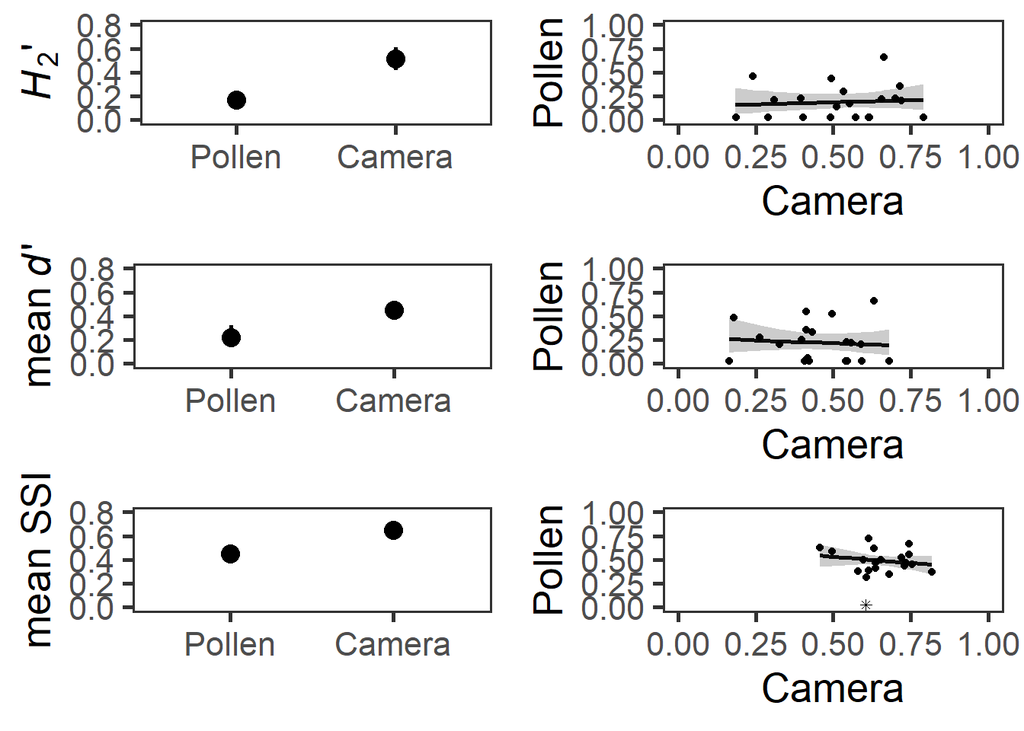

```r
all_results <- bind_rows(specialization_results_plots, correlation_results_plots) %>%
  mutate(metric = factor(metric, levels = c("H2", "d", "species.specificity.index"))) %>%
  arrange(metric, model_number)

results_multiplot <- ggarrange(plotlist = all_results$predicted_plot, ncol = 2, nrow = 3)
results_multiplot
```

## Step 6: Export results

```r
#Q1 + Q2
write.csv(results_tidy_confint, "../results/analyses_sampling_method/tables/Sampling_method_results_summary_tables.csv") #model summaries
ggsave("../results/analyses_sampling_method/figures/Sampling_method_results_multiplot.png", results_multiplot, dpi = 300, units = "in", width = 8, height = 11)

#Q1
write.csv(specialization_emmeans, "../results/analyses_sampling_method/tables/Specialization_results_emmeans.csv")
write.csv(specialization_contrasts, "../results/analyses_sampling_method/tables/Specialization_results_contrasts.csv")
ggsave("../results/analyses_sampling_method/figures/Specialization_density_plot.png", specialization_density_plot, dpi = 300, units = "in", width = 9, height = 5)
```